# Introduction to Python Project : FoodHub Data Analysis

### Problem Statement

The number of restaurants in New York is increasing day by day. Lots of students and busy professionals rely on those restaurants due to their hectic lifestyles. Online food delivery service is a great option for them. It provides them with good food from their favorite restaurants. A food aggregator company FoodHub offers access to multiple restaurants through a single smartphone app.

The app allows restaurants to receive a direct online order from a customer. The app assigns a delivery person from the company to pick up the order after it is confirmed by the restaurant. The delivery person then uses the map to reach the restaurant and waits for the food package. Once the food package is handed over to the delivery person, he/she confirms the pick-up in the app and travels to the customer's location to deliver the food. The delivery person confirms the drop-off in the app after delivering the food package to the customer. The customer can rate the order in the app. The food aggregator earns money by collecting a fixed margin on the delivery order from the restaurants.

### Objectives

The food aggregator company has stored the data of the different orders made by the registered customers in their online portal. They want to analyze the data to get a fair idea about the demand of different restaurants which will help them in enhancing their customer experience. Suppose you are hired as a Data Scientist in this company and the Data Science team has shared some of the key questions that need to be answered. Perform the data analysis to find answers to these questions that will help the company improve its business.

### Data Description

The data contains the different data related to a food order. The detailed data dictionary is given below.

### Data Dictionary

- order_id: Unique ID of the order
- customer_id: ID of the customer who ordered the food
- restaurant_name: Name of the restaurant
- cuisine_type: Cuisine ordered by the customer
- cost_of_the_order: Price paid per order
- day_of_the_week: Indicates whether the order is placed on a weekday or  
  weekend (The weekday is from Monday to Friday and the weekend is Saturday and Sunday)
- rating: Rating given by the customer out of 5
- food_preparation_time: Time (in minutes) taken by the restaurant to prepare the food. This is calculated by taking the difference between the timestamps of the restaurant's order confirmation and the delivery person's pick-up confirmation.
- delivery_time: Time (in minutes) taken by the delivery person to deliver the food package. This is calculated by taking the difference between the timestamps of the delivery person's pick-up confirmation and drop-off information

### Let us start by importing the required libraries

```python
# Write your code here to import necessary libraries for the project
import pandas as pd
import numpy as np
import matplotlib.pyplot as plt
import seaborn as sns
%matplotlib inline
```

### Understanding the structure of the data

```python
# uncomment and run the following lines for Google Colab
#from google.colab import drive
#drive.mount('/content/drive')
```

```python
# Write your code here to read the data
df = pd.read_csv('/content/foodhub_order.csv')
```

```python
# Write your code here to view the first 5 rows
df.head()
```

|  | order_id | customer_id | restaurant_name | cuisine_type | cost_of_the_order | day_of_the_week | rating | food_preparation_time | delivery_time |
| --- | --- | --- | --- | --- | --- | --- | --- | --- | --- |
| 0 | 1477147 | 337525 | Hangawi | Korean | 30.75 | Weekend | Not given | 25 | 20 |
| 1 | 1477685 | 358141 | Blue Ribbon Sushi Izakaya | Japanese | 12.08 | Weekend | Not given | 25 | 23 |
| 2 | 1477070 | 66393 | Cafe Habana | Mexican | 12.23 | Weekday | 5 | 23 | 28 |
| 3 | 1477334 | 106968 | Blue Ribbon Fried Chicken | American | 29.20 | Weekend | 3 | 25 | 15 |
| 4 | 1478249 | 76942 | Dirty Bird to Go | American | 11.59 | Weekday | 4 | 25 | 24 |

### **Question 1:** How many rows and columns are present in the data? [0.5 mark]

```python
df.shape
```

```
(1898, 9)
```

#### Observations:

- There are 1898 rows and 9 columns are present in the foodhub datset.

### **Question 2:** What are the datatypes of the different columns in the dataset? (The info() function can be used) [0.5 mark]

```python
df.info()
```

```
<class 'pandas.core.frame.DataFrame'>
RangeIndex: 1898 entries, 0 to 1897
Data columns (total 9 columns):
 #   Column                 Non-Null Count  Dtype
---  ------                 --------------  -----
 0   order_id               1898 non-null   int64
 1   customer_id            1898 non-null   int64
 2   restaurant_name        1898 non-null   object
 3   cuisine_type           1898 non-null   object
 4   cost_of_the_order      1898 non-null   float64
 5   day_of_the_week        1898 non-null   object
 6   rating                 1898 non-null   object
 7   food_preparation_time  1898 non-null   int64
 8   delivery_time          1898 non-null   int64
dtypes: float64(1), int64(4), object(4)
memory usage: 133.6+ KB
```

#### Observations:

- The datatypes of the different columns in the dataset
  - int64(4).
  - object(4).
  - float64(1).

### **Question 3:** Are there any missing values in the data? If yes, treat them using an appropriate method. [1 mark]

```python
df.isnull().sum()
```

|  | 0 |
| --- | --- |
| order_id | 0 |
| customer_id | 0 |
| restaurant_name | 0 |
| cuisine_type | 0 |
| cost_of_the_order | 0 |
| day_of_the_week | 0 |
| rating | 0 |
| food_preparation_time | 0 |
| delivery_time | 0 |

**dtype:** int64

#### Observations:

- All (1898,9) columns and rows observations have no missing values in data

### **Question 4:** Check the statistical summary of the data. What is the minimum, average, and maximum time it takes for food to be prepared once an order is placed? [2 marks]

```python
df.describe()
```

|  | order_id | customer_id | cost_of_the_order | food_preparation_time | delivery_time |
| --- | --- | --- | --- | --- | --- |
| count | 1.898000e+03 | 1898.000000 | 1898.000000 | 1898.000000 | 1898.000000 |
| mean | 1.477496e+06 | 171168.478398 | 16.498851 | 27.371970 | 24.161749 |
| std | 5.480497e+02 | 113698.139743 | 7.483812 | 4.632481 | 4.972637 |
| min | 1.476547e+06 | 1311.000000 | 4.470000 | 20.000000 | 15.000000 |
| 25% | 1.477021e+06 | 77787.750000 | 12.080000 | 23.000000 | 20.000000 |
| 50% | 1.477496e+06 | 128600.000000 | 14.140000 | 27.000000 | 25.000000 |
| 75% | 1.477970e+06 | 270525.000000 | 22.297500 | 31.000000 | 28.000000 |
| max | 1.478444e+06 | 405334.000000 | 35.410000 | 35.000000 | 33.000000 |

```python
df["food_preparation_time"].min()
```

```
20
```

```python
(df["food_preparation_time"].mean())
```

```
27.371970495258168
```

```python
df["food_preparation_time"].max()
```

```
35
```

#### Observations:

- The statistical summary of the data has been checked by using describe() function
- The minimun time it takes for food to be prepared once an order is placed is 20 minutes
- The average time it takes for food to be prepared once an order is placed is 27.37 minutes
- The maximun time it takes for food to be prepared once an order is placed is 35 minutes

### **Question 5:** How many orders are not rated? [1 mark]

```python
df["rating"].value_counts()
```

| rating | count |
| --- | --- |
| Not given | 736 |
| 5 | 588 |
| 4 | 386 |
| 3 | 188 |

**dtype:** int64

```python
df["rating"].value_counts()["Not given"]
```

```
736
```

#### Observations:

- 736 orders are not rated in the datasets

### Exploratory Data Analysis (EDA)

### **Question 6:** Explore all the variables and provide observations on their distributions. (Generally, histograms, boxplots, countplots, etc. are used for univariate exploration.) [9 marks]

```python
df.nunique()
```

|  | 0 |
| --- | --- |
| order_id | 1898 |
| customer_id | 1200 |
| restaurant_name | 178 |
| cuisine_type | 14 |
| cost_of_the_order | 312 |
| day_of_the_week | 2 |
| rating | 4 |
| food_preparation_time | 16 |
| delivery_time | 19 |

**dtype:** int64

```python
df["order_id"].nunique()
```

```
1898
```

Observations:

- A total of 1898 unique orders IDs were made by various customers.

```python
df["customer_id"].nunique()
```

```
1200
```

```python
df["customer_id"].value_counts().value_counts(ascending=True)
```

| count | count |
| --- | --- |
| 13 | 1 |
| 10 | 1 |
| 9 | 1 |
| 8 | 1 |
| 7 | 4 |
| 6 | 6 |
| 5 | 19 |
| 4 | 33 |
| 3 | 83 |
| 2 | 267 |
| 1 | 784 |

**dtype:** int64

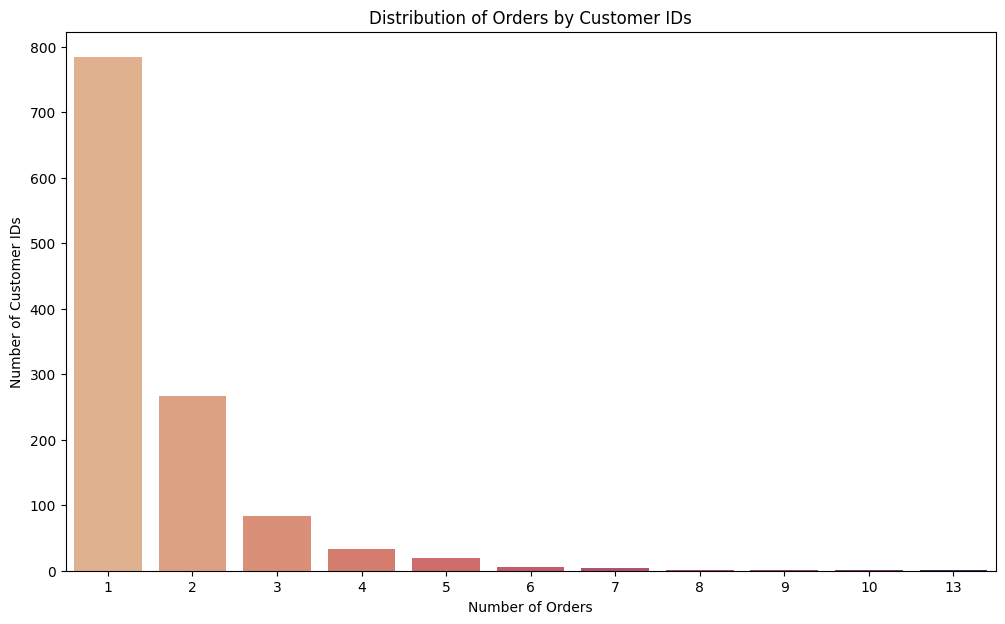

```python
figsize = (12,7)
fig, ax = plt.subplots(figsize=figsize)
data = df["customer_id"].value_counts().value_counts(ascending=True)
sns.barplot(y=data, x=data.index, hue=data.index, palette="flare", legend=False);
plt.xlabel("Number of Orders")
plt.ylabel("Number of Customer IDs")
plt.title("Distribution of Orders by Customer IDs")
plt.show()
```

#### Observations:

- There were a total of 1200 unique customer IDs and different customers who placed orders.
- The maximum number of orders made from an account was 13 orders.
- 784 customer only placed single orders

```python
df["restaurant_name"].nunique()
```

```
178
```

```python
df['restaurant_name'].value_counts().head(10)
```

| restaurant_name | count |
| --- | --- |
| Shake Shack | 219 |
| The Meatball Shop | 132 |
| Blue Ribbon Sushi | 119 |
| Blue Ribbon Fried Chicken | 96 |
| Parm | 68 |
| RedFarm Broadway | 59 |
| RedFarm Hudson | 55 |
| TAO | 49 |
| Han Dynasty | 46 |
| Blue Ribbon Sushi Bar & Grill | 44 |

**dtype:** int64

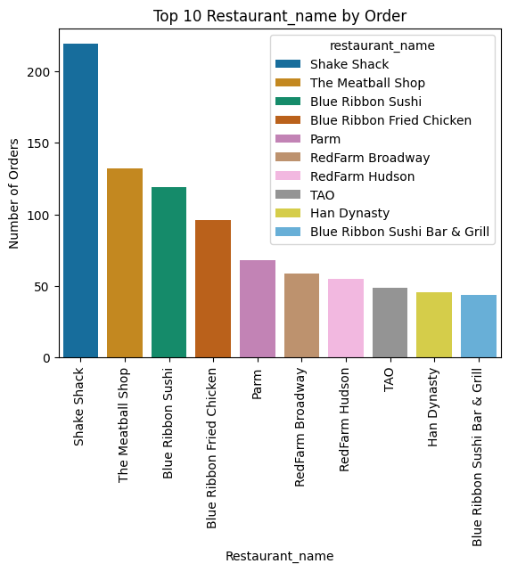

```python
data=df["restaurant_name"].value_counts().head(10)
figsize = (12,7)
sns.barplot(y=data, x=data.index, hue=data.index, palette="colorblind", legend=True);
plt.title("Top 10 Restaurant_name by Order")
plt.xlabel("Restaurant_name")
plt.xticks(rotation=90)
plt.ylabel("Number of Orders")
plt.show()
```

#### Observations:

- There are 178 restaurants names in datasets and received the orders.
- The highest number of orders is 219 and it was in Shake Shack restaurant.
- Only 3 of the restaurants has crossed above 100 numbers of orders.

```python
df["cuisine_type"].nunique()
```

```
14
```

```python
df["cuisine_type"].value_counts()
```

| cuisine_type | count |
| --- | --- |
| American | 584 |
| Japanese | 470 |
| Italian | 298 |
| Chinese | 215 |
| Mexican | 77 |
| Indian | 73 |
| Middle Eastern | 49 |
| Mediterranean | 46 |
| Thai | 19 |
| French | 18 |
| Southern | 17 |
| Korean | 13 |
| Spanish | 12 |
| Vietnamese | 7 |

**dtype:** int64

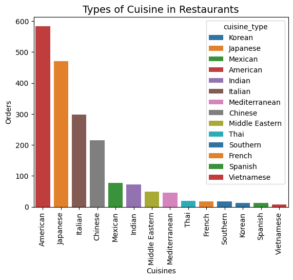

```python
sns.countplot(data=df, x="cuisine_type", hue="cuisine_type",
              order=df['cuisine_type'].value_counts().index, palette="tab10", legend=True);
plt.xticks(rotation=90)
plt.ylabel("Orders")
plt.xlabel("Cuisines")
plt.title("Types of Cuisine in Restaurants", size=14)
plt.show()
```

Observations:

- There are 14 cuisines in the restaurant.
- The highest number of order in cuisines is American at 584.
- The most ordered cuisines are American,Japanese,Italian and chinese.
- The least number of order from the above plot is Korean,Spanish,Vietnamese.
- 4 of the cuisines crossed above 200 orders.

```python
df["cost_of_the_order"].nunique()
```

```
312
```

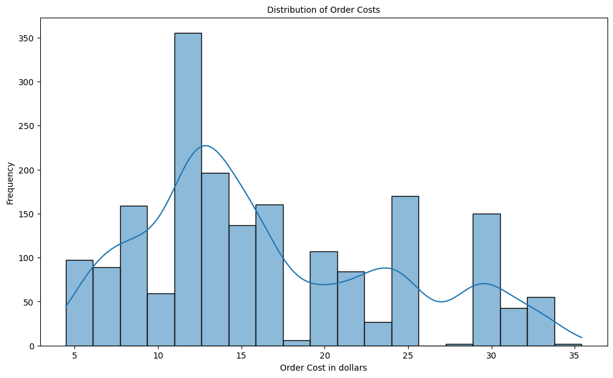

```python
plt.figure(figsize = (12,7))
sns.histplot(data=df, x="cost_of_the_order", kde=True)
plt.ylabel("Frequency")
plt.title("Distribution of Order Costs", size=10)
plt.xlabel("Order Cost in dollars")
plt.show()
```

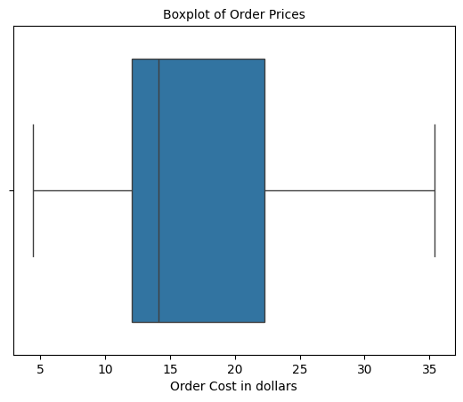

```python
sns.boxplot(data=df, x="cost_of_the_order");
plt.xlabel("Order Cost in dollars")
plt.title("Boxplot of Order Prices", size=10)
```

Observations:

- The cost of the order follows the Right-Skewed distribution.
- The most of the orders are less than 25 dollors.

```python
df["day_of_the_week"].nunique()
```

```
2
```

```python
df["day_of_the_week"].value_counts()
```

| day_of_the_week | count |
| --- | --- |
| Weekend | 1351 |
| Weekday | 547 |

**dtype:** int64

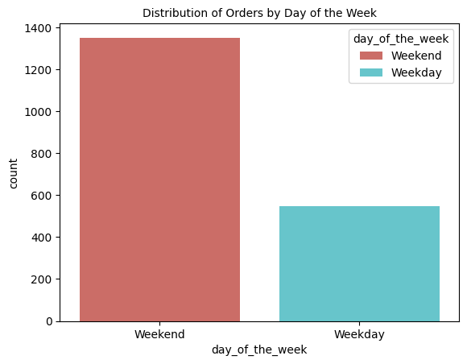

```python
sns.countplot(data=df, x='day_of_the_week', hue='day_of_the_week', palette="hls", legend=True)
plt.title("Distribution of Orders by Day of the Week", size=10)
plt.show()
```

Observations:

- The most of the order are placed in the weekends

```python
df["rating"].nunique()
```

```
4
```

```python
df["rating"].value_counts(normalize=True)
```

| rating | proportion |
| --- | --- |
| Not given | 0.387777 |
| 5 | 0.309800 |
| 4 | 0.203372 |
| 3 | 0.099052 |

**dtype:** float64

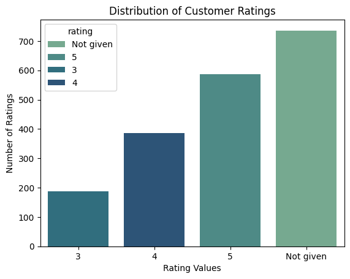

```python
sns.countplot(data=df, x="rating", hue="rating",
              order=df["rating"].value_counts(ascending=True).index,
              palette="crest", legend=True)
plt.title("Distribution of Customer Ratings")
plt.xlabel("Rating Values")
plt.ylabel("Number of Ratings")
plt.show()
```

```python
df["food_preparation_time"].nunique()
```

```
16
```

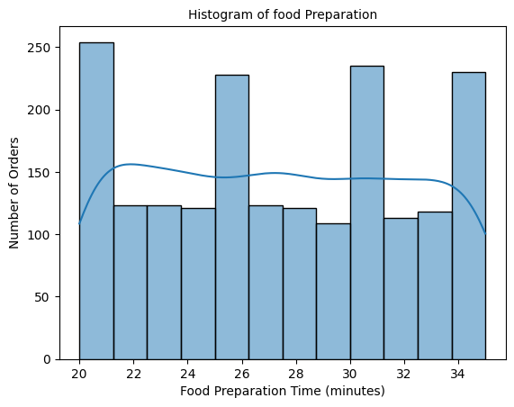

```python
sns.histplot(data=df, x="food_preparation_time", kde=True);
plt.xlabel("Food Preparation Time (minutes)")
plt.title("Histogram of food Preparation",size=10)
plt.ylabel("Number of Orders")
plt.show()
```

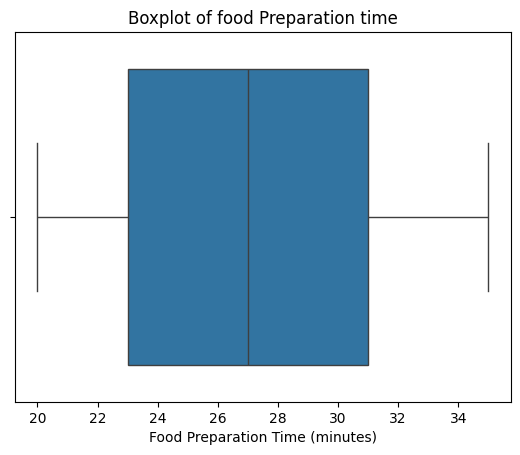

```python
sns.boxplot(data=df, x="food_preparation_time");
plt.xlabel("Food Preparation Time (minutes)")
plt.title("Boxplot of food Preparation time")
plt.show()
```

```python
df["delivery_time"].nunique()
```

```
19
```

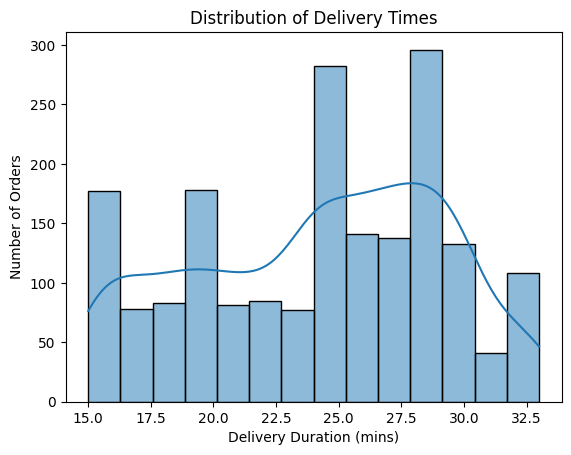

```python
sns.histplot(data=df, x="delivery_time",kde=True);
plt.xlabel("Delivery Duration (mins)")
plt.ylabel("Number of Orders")
plt.title("Distribution of Delivery Times")
plt.show()
```

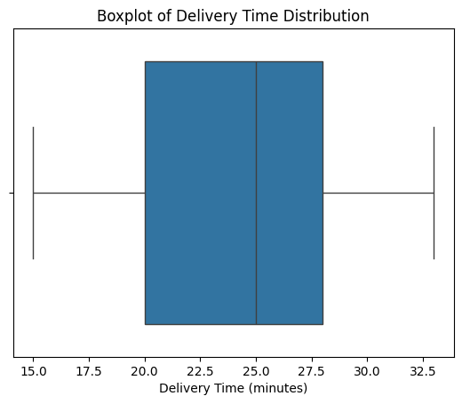

```python
sns.boxplot(data=df, x="delivery_time");
plt.xlabel("Delivery Time (minutes)")
plt.title("Boxplot of Delivery Time Distribution")
plt.show()
```

Observations:

- The Delivery Time is left skewed distribution.
- The median delivery time for the orders made was 25 minutes.

### **Question 7**: Which are the top 5 restaurants in terms of the number of orders received? [1 mark]

```python
df['restaurant_name'].value_counts().head()
```

| restaurant_name | count |
| --- | --- |
| Shake Shack | 219 |
| The Meatball Shop | 132 |
| Blue Ribbon Sushi | 119 |
| Blue Ribbon Fried Chicken | 96 |
| Parm | 68 |

**dtype:** int64

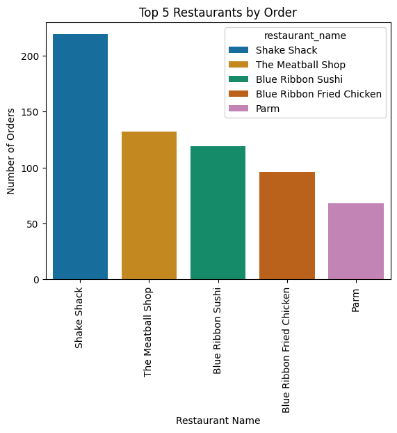

```python
data = df["restaurant_name"].value_counts().head()
sns.barplot(x=data.index, y=data, hue=data.index, palette="colorblind", legend=True)
plt.title("Top 5 Restaurants by Order")
plt.xlabel("Restaurant Name")
plt.xticks(rotation=90)
plt.ylabel("Number of Orders")
plt.show()
```

#### Observations:

The top 5 restaurants in terms of the number of orders received are

- Shake Shack with 219 orders.
- The Meatball Shop with 132 orders.
- Blue Ribbon Sushi with 119 orders.
- Blue Ribbon Fried Chicken with 96 orders.
- Parm with 68 orders.

### **Question 8**: Which is the most popular cuisine on weekends? [1 mark]

```python
df[df["day_of_the_week"]=="Weekend"]["cuisine_type"].value_counts()
```

| cuisine_type | count |
| --- | --- |
| American | 415 |
| Japanese | 335 |
| Italian | 207 |
| Chinese | 163 |
| Mexican | 53 |
| Indian | 49 |
| Mediterranean | 32 |
| Middle Eastern | 32 |
| Thai | 15 |
| French | 13 |
| Korean | 11 |
| Southern | 11 |
| Spanish | 11 |
| Vietnamese | 4 |

**dtype:** int64

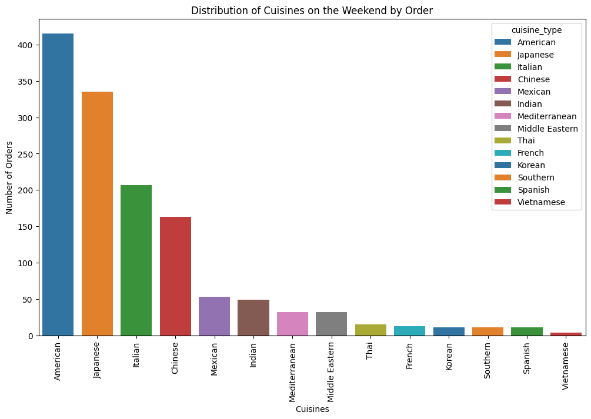

```python
figsize = (12, 7)
fig, ax = plt.subplots(figsize=figsize)
data = df[df["day_of_the_week"] == "Weekend"]["cuisine_type"].value_counts()
sns.barplot(x=data.index, y=data, hue=data.index, palette="tab10", ax=ax, legend=True)
plt.title("Distribution of Cuisines on the Weekend by Order")
plt.xlabel("Cuisines")
plt.xticks(rotation=90)
plt.ylabel("Number of Orders")
plt.show()
```

#### Observations:

- The most popular cuisine on weekends is American with 415 orders.

### **Question 9**: What percentage of the orders cost more than 20 dollars? [2 marks]

```python
a = df["cost_of_the_order"][df["cost_of_the_order"] > 20].count()
print(format(a))
```

```
555
```

```python
total_orders = df["cost_of_the_order"].count()
percentage = float(a / total_orders) * 100
print(percentage)
```

```
29.24130663856691
```

#### Observations:

- The number of orders that costed more than 20 dollars is 555 orders.
- 29.24% of the total orders cost more than 20 dollars in the dataset.

### **Question 10**: What is the mean order delivery time? [1 mark]

```python
df["delivery_time"].mean()
```

```
24.161749209694417
```

#### Observations:

- The mean order delivery time is 24.162 minutes.

### **Question 11:** The company has decided to give 20% discount vouchers to the top 3 most frequent customers. Find the IDs of these customers and the number of orders they placed. [1 mark]

```python
df["customer_id"].value_counts().head(3)
```

| customer_id | count |
| --- | --- |
| 52832 | 13 |
| 47440 | 10 |
| 83287 | 9 |

**dtype:** int64

#### Observations:

The top 3 most frequent customers that company decided to give 20% discount vouchers

- Customer ID 52832 with 13 orders
- Customer ID 47440 with 10 orders
- Customer ID 83287 with 9 orders

### **Question 12**: Perform a multivariate analysis to explore relationships between the important variables in the dataset. (It is a good idea to explore relations between numerical variables as well as relations between numerical and categorical variables) [10 marks]

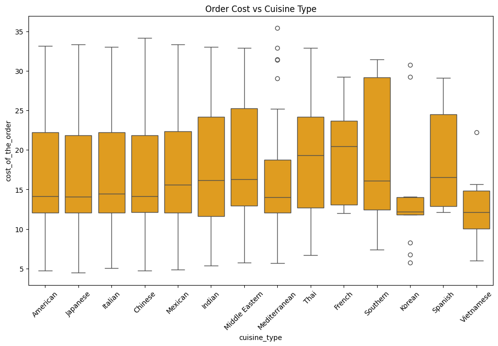

```python
plt.figure(figsize=(12, 7))
sns.boxplot(x='cuisine_type',order=df['cuisine_type'].value_counts().index, y='cost_of_the_order', data=df,color= "orange")
plt.title("Order Cost vs Cuisine Type")
plt.xticks(rotation=45)
plt.show()
```

#### Observations:

- The median order cost of the different cuisines falls between 10 and 23 dollars.
- Most of the cuisines in the dataset are right skewed and positive.
- The Southern Cuisine had the highest interquartile range (IQR) - it has the longest box.
- Some of the cuisines types had outliers in the cost of the order column of the dataset.

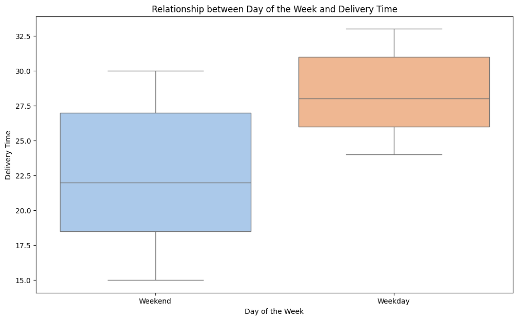

```python
plt.figure(figsize=(12, 7))
sns.boxplot(x="day_of_the_week", y="delivery_time", hue="day_of_the_week", data=df, palette="pastel", legend=False)
plt.title("Relationship between Day of the Week and Delivery Time")
plt.xlabel("Day of the Week")
plt.ylabel("Delivery Time")
plt.show()
```

#### Observations:

- The Weekend of the week had a higher IQR than the Weekday as it has a bigger box.
- Delivery time is right skewed on both weekdays and weekends.
- There are no outliers in the Day of the Week column of the dataset.
- Orders made on the weekday had a higher delivery time than orders made on the weekend.

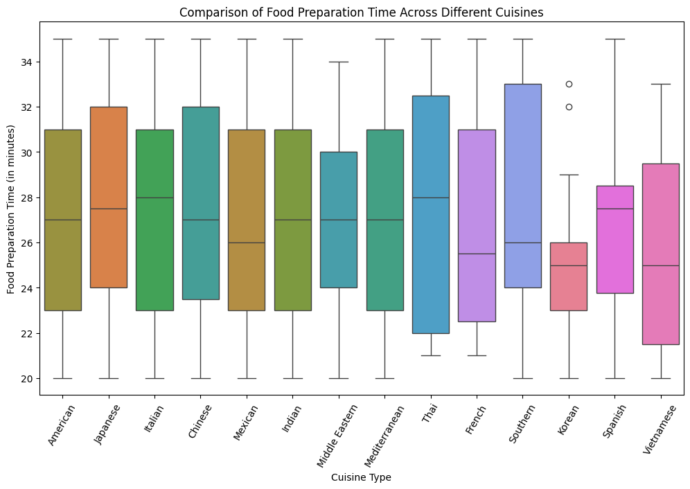

```python
plt.figure(figsize=(12, 7))
sns.boxplot(x="cuisine_type", hue="cuisine_type", order=df['cuisine_type'].value_counts().index,
            y="food_preparation_time", data=df, palette='husl', legend=False)
plt.xticks(rotation=60)
plt.title("Comparison of Food Preparation Time Across Different Cuisines")
plt.xlabel("Cuisine Type")
plt.ylabel("Food Preparation Time (in minutes)")
plt.show()
```

#### Observations:

- The Thai cuisine had the highest IQR out of all the cuisines listed as it had the longest box.
- The Korean cuisine had outliers in the dataset.

```python
df.groupby(['restaurant_name']) ['cost_of_the_order'].sum().sort_values(ascending = False).head(10)
```

| restaurant_name | cost_of_the_order |
| --- | --- |
| Shake Shack | 3579.53 |
| The Meatball Shop | 2145.21 |
| Blue Ribbon Sushi | 1903.95 |
| Blue Ribbon Fried Chicken | 1662.29 |
| Parm | 1112.76 |
| RedFarm Broadway | 965.13 |
| RedFarm Hudson | 921.21 |
| TAO | 834.50 |
| Han Dynasty | 755.29 |
| Blue Ribbon Sushi Bar & Grill | 666.62 |

**dtype:** float64

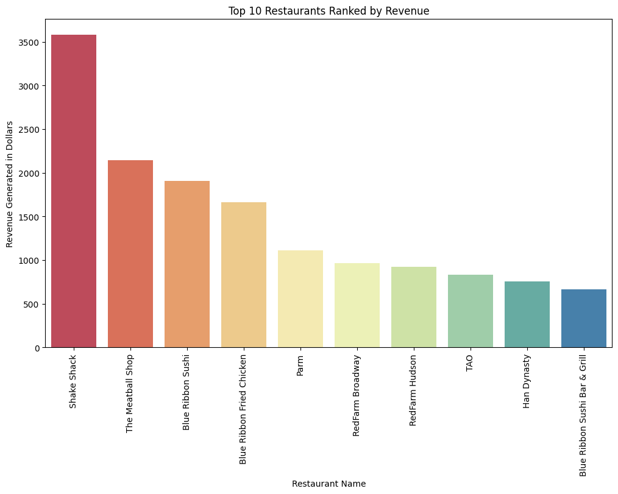

```python
figsize = (12, 7)
fig, ax = plt.subplots(figsize=figsize)
data = df.groupby(['restaurant_name'])['cost_of_the_order'].sum().sort_values(ascending=False).head(10)
sns.barplot(x=data.index, y=data, hue=data.index, palette="Spectral", ax=ax, legend=False)
plt.title("Top 10 Restaurants Ranked by Revenue")
plt.xlabel("Restaurant Name")
plt.xticks(rotation=90)
plt.ylabel("Revenue Generated in Dollars")
plt.show()
```

#### Observations:

- The Shake Shack restaurant generated the highest revenue and the highest number of orders.
- Only 5 of the restaurants listed generated a revenue above 1000 dollars.

```python
df["rating"].value_counts()
```

| rating | count |
| --- | --- |
| Not given | 736 |
| 5 | 588 |
| 4 | 386 |
| 3 | 188 |

**dtype:** int64

```python
data=df.copy()
data.drop(data[data['rating'] == "Not given"].index, axis=0, inplace=True)
data["rating"].astype("int")
data.head(10)
```

|  | order_id | customer_id | restaurant_name | cuisine_type | cost_of_the_order | day_of_the_week | rating | food_preparation_time | delivery_time |
| --- | --- | --- | --- | --- | --- | --- | --- | --- | --- |
| 2 | 1477070 | 66393 | Cafe Habana | Mexican | 12.23 | Weekday | 5 | 23 | 28 |
| 3 | 1477334 | 106968 | Blue Ribbon Fried Chicken | American | 29.20 | Weekend | 3 | 25 | 15 |
| 4 | 1478249 | 76942 | Dirty Bird to Go | American | 11.59 | Weekday | 4 | 25 | 24 |
| 5 | 1477224 | 147468 | Tamarind TriBeCa | Indian | 25.22 | Weekday | 3 | 20 | 24 |
| 7 | 1477859 | 89574 | Barbounia | Mediterranean | 5.97 | Weekday | 3 | 33 | 30 |
| 8 | 1477174 | 121706 | Anjappar Chettinad | Indian | 16.44 | Weekday | 5 | 21 | 26 |
| 9 | 1477311 | 39705 | Bukhara Grill | Indian | 7.18 | Weekday | 5 | 29 | 26 |
| 11 | 1478437 | 221206 | Empanada Mama (closed) | Mexican | 8.10 | Weekend | 5 | 23 | 22 |
| 12 | 1476966 | 129969 | Blue Ribbon Fried Chicken | American | 24.30 | Weekend | 5 | 23 | 17 |
| 13 | 1477449 | 104548 | Pylos | Mediterranean | 11.30 | Weekend | 3 | 24 | 23 |

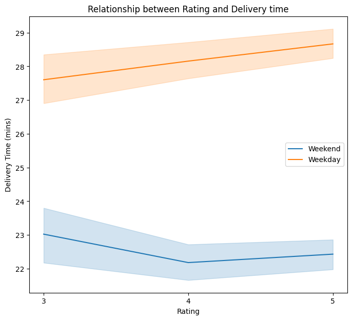

```python
data=data.sort_values("rating")
plt.figure(figsize=(8, 7))
sns.lineplot(x = 'rating', y = 'delivery_time', hue="day_of_the_week",data = data)
plt.ylabel("Delivery Time (mins)")
plt.xlabel("Rating")
plt.title("Relationship between Rating and Delivery time")
plt.legend(loc="center right")
plt.show()
```

#### Observations:

- On the weekday, there is a positive correlation between rating and delivery time.
- On the weekend, there is a rather negative correlation between rating and delivery time.
- Delivery time is higher on the weekday than on the weekends.

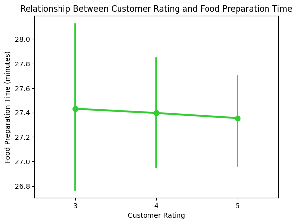

```python
sns.pointplot(x="rating", y='food_preparation_time', data=data, color="limegreen")
plt.title("Relationship Between Customer Rating and Food Preparation Time")
plt.xlabel("Customer Rating")
plt.ylabel("Food Preparation Time (minutes)")
plt.show()
```

#### Observation:

- we can observe that there is a negative correlation between Customer Rating and Food Preparation Time.

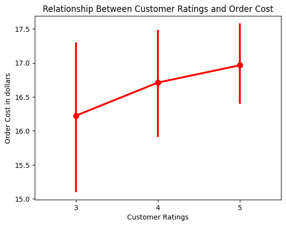

```python
sns.pointplot(x="rating", y="cost_of_the_order", data=data, color="red");
plt.title("Relationship Between Customer Ratings and Order Cost")
plt.xlabel("Customer Ratings")
plt.ylabel("Order Cost in dollars")
plt.show()
```

#### Observation:

- We can observe that there is a positive correlation between Customer Ratings and Cost of the Order.

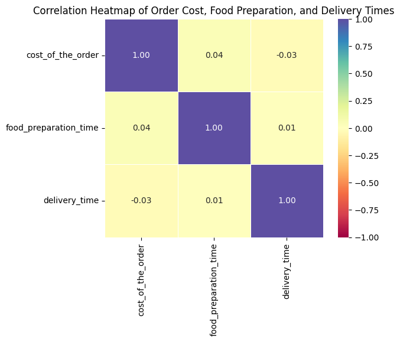

```python
col_list = ['cost_of_the_order', 'food_preparation_time', 'delivery_time']
sns.heatmap(df[col_list].corr(), annot=True, vmin=-1, vmax=1, linewidths=0.5,fmt=".2f", cmap="Spectral", square=True);
plt.title("Correlation Heatmap of Order Cost, Food Preparation, and Delivery Times")
plt.show()
```

#### Observations:

- Delivery time and cost of the order have a negative correlation (-0.03).
- Food preparation time and Cost of the Order have the highest correlation (0.04).

### **Question 13:** The company wants to provide a promotional offer in the advertisement of the restaurants. The condition to get the offer is that the restaurants must have a rating count of more than 50 and the average rating should be greater than 4. Find the restaurants fulfilling the criteria to get the promotional offer. [3 marks]

```python
df_rated = df[df['rating'] != 'Not given'].copy()
df_rated['rating'] = df_rated['rating'].astype('int')
df_rating_count = df_rated.groupby(['restaurant_name'])['rating'].count().sort_values(ascending = False).reset_index()
df_rating_count.head()
```

|  | restaurant_name | rating |
| --- | --- | --- |
| 0 | Shake Shack | 133 |
| 1 | The Meatball Shop | 84 |
| 2 | Blue Ribbon Sushi | 73 |
| 3 | Blue Ribbon Fried Chicken | 64 |
| 4 | RedFarm Broadway | 41 |

```python
df_rated.rating.count()
```

```
1162
```

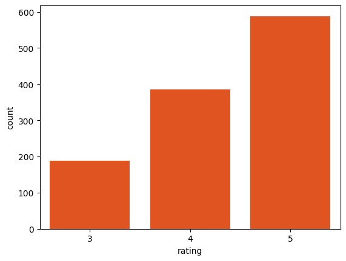

```python
sns.countplot(data=df_rated,x='rating',color='orangered')
plt.show()
```

```python
restaurant=df_rated.groupby('restaurant_name')['rating'].mean().sort_values(ascending=False).reset_index()
print(restaurant[restaurant.rating>=4])
```

```
                   restaurant_name  rating
0                       'wichcraft     5.0
1             Ravagh Persian Grill     5.0
2    Chola Eclectic Indian Cuisine     5.0
3                      Chote Nawab     5.0
4                           Junoon     5.0
..                             ...     ...
134                   Pongsri Thai     4.0
135               Frank Restaurant     4.0
136               Dirty Bird to Go     4.0
137                      Rye House     4.0
138                  DuMont Burger     4.0

[139 rows x 2 columns]
```

```python
df_rated.groupby('restaurant_name')['rating'].count().sort_values(ascending=False).reset_index().head()
```

|  | restaurant_name | rating |
| --- | --- | --- |
| 0 | Shake Shack | 133 |
| 1 | The Meatball Shop | 84 |
| 2 | Blue Ribbon Sushi | 73 |
| 3 | Blue Ribbon Fried Chicken | 64 |
| 4 | RedFarm Broadway | 41 |

```python
rest_names = df_rating_count[df_rating_count["rating"] >50]['restaurant_name']
df_mean = df_rated[df_rated['restaurant_name'].isin(rest_names)].copy()
df_mean.head(5)
data= df_mean.groupby(['restaurant_name'])["rating"].mean().sort_values(ascending = False).reset_index().dropna()
data
```

|  | restaurant_name | rating |
| --- | --- | --- |
| 0 | The Meatball Shop | 4.511905 |
| 1 | Blue Ribbon Fried Chicken | 4.328125 |
| 2 | Shake Shack | 4.278195 |
| 3 | Blue Ribbon Sushi | 4.219178 |

#### Observations:

- The following restaurants qualify for this promotional offer: Shake Shack, The Meatball Shop, Blue Ribbon Sushi, and Blue Ribbon Fried Chicken.
- The Meatball Shop had the highest average rating of 4.512.
- 139 restaurants have a mean rating for all orders of greater than or equal to 4.
- Only 4 restaurants have 50 or more orders with ratings.

### **Question 14:** The company charges the restaurant 25% on the orders having cost greater than 20 dollars and 15% on the orders having cost greater than 5 dollars. Find the net revenue generated by the company across all orders. [3 marks]

```python
revenue1_df = df[df['cost_of_the_order'] > 20]
amount1 = revenue1_df['cost_of_the_order'].sum() * 0.25
```

```python
revenue2_df = df[df['cost_of_the_order'] <= 20]
amount2 = revenue2_df[revenue2_df['cost_of_the_order'] > 5]['cost_of_the_order'].sum() * 0.15
```

```python
net_revenue = amount1 + amount2
print(round(net_revenue,2))
```

```
6166.3
```

#### Observations:

- The net revenue generated by the company across all orders is 6166.3 dollars.

### **Question 15:** The company wants to analyze the total time required to deliver the food. What percentage of orders take more than 60 minutes to get delivered from the time the order is placed? (The food has to be prepared and then delivered.) [2 marks]

```python
df['total_time'] = df['food_preparation_time'] + df['delivery_time']
df.head()
```

|  | order_id | customer_id | restaurant_name | cuisine_type | cost_of_the_order | day_of_the_week | rating | food_preparation_time | delivery_time | total_time |
| --- | --- | --- | --- | --- | --- | --- | --- | --- | --- | --- |
| 0 | 1477147 | 337525 | Hangawi | Korean | 30.75 | Weekend | Not given | 25 | 20 | 45 |
| 1 | 1477685 | 358141 | Blue Ribbon Sushi Izakaya | Japanese | 12.08 | Weekend | Not given | 25 | 23 | 48 |
| 2 | 1477070 | 66393 | Cafe Habana | Mexican | 12.23 | Weekday | 5 | 23 | 28 | 51 |
| 3 | 1477334 | 106968 | Blue Ribbon Fried Chicken | American | 29.20 | Weekend | 3 | 25 | 15 | 40 |
| 4 | 1478249 | 76942 | Dirty Bird to Go | American | 11.59 | Weekday | 4 | 25 | 24 | 49 |

```python
a=df["total_time"][df["total_time"]>60].count()
print(format(a))
```

```
200
```

```python
percentage = (a/ df.shape[0]) * 100
print((round(percentage,2)))
```

```
10.54
```

#### Observations:

- The number of orders that take more than 60 minutes is 200 orders.
- The percentage of orders have more than 60 minutes of total delivery time is 10.54%.

### **Question 16:** The company wants to analyze the delivery time of the orders on weekdays and weekends. How does the mean delivery time vary during weekdays and weekends? [2 marks]

```python
df.day_of_the_week.unique()
```

```
array(['Weekend', 'Weekday'], dtype=object)
```

```python
weekends=df[df.day_of_the_week=='Weekend']
```

```python
weekdays=df[df.day_of_the_week=='Weekday']
```

```python
weekend_dtime=round(weekends.delivery_time.mean(),2)
print(weekend_dtime)
```

```
22.47
```

```python
weekday_dtime=round(weekdays.delivery_time.mean(),2)
print(weekday_dtime)
```

```
28.34
```

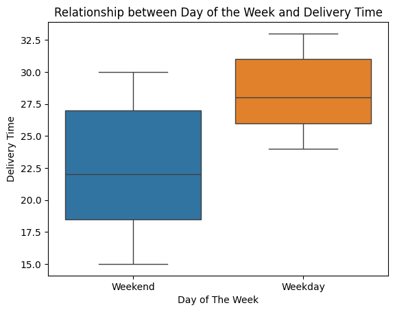

```python
sns.boxplot(y="delivery_time", x="day_of_the_week", hue="day_of_the_week",
            data=df, palette="tab10", legend=False)
plt.title("Relationship between Day of the Week and Delivery Time")
plt.xlabel("Day of The Week")
plt.ylabel("Delivery Time")
plt.show()
```

#### Observations:

- The mean delivery time on a Weekend is around 22.47 minutes.
- The mean delivery time on a Weekday is around 28.34 minutes.
- The Weekend has a lower average delivery time compared to the Weekdays.
- The Weekend day of the week had a higher IQR than the Weekday as it has a bigger box.

### Conclusion and Recommendations

### **Question 17:** What are your conclusions from the analysis? What recommendations would you like to share to help improve the business? (You can use cuisine type and feedback ratings to drive your business recommendations.) [6 marks]

### Conclusions:

- A significant number of orders were placed without customer ratings.
- The average rating of the rated orders was 4.34
- Cuisine like Americans, Japanese, and Italian food are the most popular choices, especially American on weekends received a higher number of orders as compared to other cuisine.
- Customers waited longer for their orders to arrive on weekdays compared to weekends.
- Most orders cost less than $20.
- The company's revenue model, charging restaurants based on the ordercost is in net revenue of $6166.3

### Recommendations:

- FoodHub could offer discounts or rewards for many orders, especially since many customers only made a one order.
- Restaurant with a low number of orders should look into increasing the quality of food and introduce new cuisines to increase the number of orders to give customers.
- Always pay attention to customer feedback so we can improve and think of new things. This helps us focus on what our customers want.
- Only four types of food were really popular, with more than 200 orders. FoodHub could try advertising, giving incentives, or offering discounts to get people interested in the other types of food and make them more popular.